# LAB ASSIGNMENT 07 OF IMAGE SIGNAL PROCESSING

## DFT, Magnitude-Phase Dominance, and Rotation Property

**MANSI KAKKAR**

**EE21S063**

**IMPORTING LIBRARIES**

```python
import imageio as io
import numpy as np
import math
import matplotlib.pyplot as plt
from numpy.fft import fftshift, fft
```

```python
!ls
```

```
Lab_07.pdf            fourier.png           peppers_small.pgm
PA(7)_EE21S063.ipynb  fourier_transform.pgm peppers_small.png
fourier.pgm           fourier_transform.png
```

**READING THE IMAGES**

```python
#reading fourier and fourier transform image
fourier = io.imread('fourier.png')
fourier_transform = io.imread('fourier_transform.png')
```

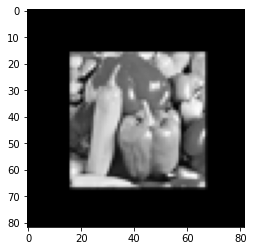

```python
#reading peppers image
peppers = io.imread('peppers_small.png')
plt.imshow(peppers,'gray')
```

**DISPLAYING THE IMAGES**

[figure not shown]

[figure not shown]

```python
plt.figure(figsize = (6,6))
plt.imshow(fourier,cmap = 'gray')
plt.show()
plt.figure(figsize = (6,6))
plt.imshow(fourier_transform,cmap = 'gray')
plt.show()
```

**FUNCTION FOR BILINEAR INTERPOLATION**

```python
#FUNCTION FOR BILINEAR INTERPOLATION

def bilinear_interpolation(source,x,y):

    #taking coordinates of zero padded image
    xz,yz=np.shape(source)
    #original coordinates of image
    xz=xz-2
    yz=yz-2

    #taking x+1 and y+1 since coordinates have to be aligned to the zero padded image
    #zero padded image has one coordinate +1 due to padding hence target image coordinate is incremented by 1
    x=x+1
    y=y+1

    #defining x',y' as floor of x,y
    x_prime=math.floor(x)
    y_prime=math.floor(y)
    #defining a,b as distance of target point from floor points
    a=x-x_prime
    b=y-y_prime

    if x_prime>=0 and x_prime<=xz and y_prime>=0 and y_prime<=yz:
        #calculating the intensity at the target
        intensity = (1-a)*(1-b)*source[x_prime,y_prime]+(1-a)*b*source[x_prime,y_prime+1]+a*(1-b)*source[x_prime+1,y_prime]+a*b*source[x_prime+1,y_prime+1]
        #converting intensity into integer as intensity value cannot be float
        intensity=int(intensity)
    else:
        #when xs and ys are not defined i.e. xs and ys are <0 for corresponding target location
        intensity = 0

    return intensity
```

**FUNCTION FOR ROTATION**

```python
#FUNCTION FOR ROTATION

def rotation(source_image, theta):

  #reading image size
  x , y = np.shape(source_image)

  #creating a blank image
  rot_image=np.zeros((x,y))

  #zero padded source image
  zero_padded_image=np.zeros((x+2,y+2))
  zero_padded_image[1:-1,1:-1]=source_image

  #calculating center coordinates sicne rotation of the image has to be done about the center of the image
  x_center=x/2
  y_center=y/2

  #theta : degrees to radians
  theta=theta*(np.pi)/180

  #nested for loops for target coorinates ranging to source coordinates
  for xt in range(x):
    for yt in range(y):
      #every target point to be rotated about the center
      xt_c=xt-x_center
      yt_c=yt-y_center

      #applying clockwise rotation matrix :
      #   [Xt] = [clockwise rotation matrix][Xs]
      #   Considering inverse rotation matrix
      xs = np.cos(theta)*xt_c - np.sin(theta)*yt_c + x_center
      ys = np.sin(theta)*xt_c + np.cos(theta)*yt_c + y_center
      intensity=bilinear_interpolation(zero_padded_image,xs,ys)
      rot_image[xt,yt]=intensity

  return rot_image
```

**2D DFT FUNCTION**

Calculating 2D DFT of image. Use the separability property of 2D DFT to break it into row and column transforms. The row and column transforms can be performed using a 1D DFT.

```python
def dft_2d(source):
    #getting shape of source
    x,y = np.shape(source)

    #row transform
    transform_r = fft(source, axis=1)
    #transform on row transformed image
    dft_transform = fft(transform_r, axis=0)
    #fftshift to the center for more intuitive visualization
    dft_transform = fftshift(dft_transform)

    # getting the magnitude and phase
    mag = np.abs(dft_transform)
    phase = np.zeros_like(dft_transform)
    phase[mag!=0] = dft_transform[mag!=0]/mag[mag!=0]

    return mag, phase
```

**IDFT FUNCTION**

Calculate the 2D IDFT for the given image. Implementation is very similar to the dft_2D function. Use the property that taking DFT of the DFT of an image gives a flipped image to compute the IDFT.

```python
def idft_2d(mag, phase, shift_first = True):
    #get dft from given maginitude and phase
    dft = mag*phase
    #getting shape of dft
    x,y = np.shape(dft)

    if shift_first:
        dft = fftshift(dft)
    #row transform
    transform_r = fft(dft, axis=1)
    #transform on row transformed image
    transform = fft(transform_r, axis=0)
    #fftshift to the center for more intuitive visualization
    if not shift_first:
        transform = fftshift(transform)
    #magnitude
    mag = np.abs(transform)
    # flipping the image
    mag = mag[::-1, ::-1]

    return mag
```

**FUNCTION FOR PHASE SWAPPING AND OBSERVING THE OUTPUT**

Checking for the effect of swapping the phases of the images, and seeing what effect the phases cause on the image. As given in the question $F_{1}(k,l) = |F_{1}(k, l)|e^{j\Phi_{1}(k, l)}$ and $F_{2}(k,l) = |F_{2}(k, l)|e^{j\Phi_{2}(k, l)}$ are DFTs of I1 and I2 respectively.

We have to create two new images such that I3 and I4 are $F_{1}(k,l) = |F_{1}(k, l)|e^{j\Phi_{2}(k, l)}$ and $F_{2}(k,l) = |F_{2}(k, l)|e^{j\Phi_{1}(k, l)}$ respectively

```python
def phase_swap(img1, img2):
    #get DFTs of both the images
    m1, p1 = dft_2d(img1)
    m2, p2 = dft_2d(img2)
    #getting the swapped phases images
    img12 = idft_2d(m1, p2)
    img21 = idft_2d(m2, p1)
    return img12, img21
```

**ROTATION USING DFT**

Compute rotated form of 2D DFT such that the image center is the origin as:

$F(k,l) = \sum_m \sum_n f(m,n)\exp{-j\frac{2\pi}{N}{m'}^TR{k'}}$

where

${m'}=[m n]^T$

and

${k'}=\begin{bmatrix} \frac{k-\frac{M}{2}}{M} & \frac{l-\frac{N}{2}}{N} \end{bmatrix}^T$

and Rotation Matrix is

$R = \begin{bmatrix} \cos(\theta) & -\sin(\theta) \\ \sin(\theta) & \cos(\theta) \end{bmatrix}$

```python
def rotated_dft(image, theta):

    theta *= np.pi/180
    #Rotation matrix
    rot_mat = np.array([[np.cos(theta), -np.sin(theta)],[np.sin(theta), np.cos(theta)]])

    # get the shape of the image
    x, y = np.shape(image)

    # make a canvas of zeroes ensure that the data type is complex
    F = np.zeros((x, y), dtype=np.complex)

    # use meshgrid for vectorized operations
    X, Y = np.meshgrid(np.arange(x), np.arange(y))

    # get the image center
    x_c = x//2
    y_c = y//2

    #reshaping
    m_vec = np.hstack((X.reshape(-1, 1)-x_c, Y.reshape(-1, 1)-y_c))
    for i in range(x):
        for j in range(y):
            # get the k vector as mentioned
            k_vec = np.array([(i-x_c)/x, (j-y_c)/y])
            k_vec = (rot_mat@k_vec)
            vals = m_vec@k_vec
            # performing vectorized multiplication and reshaping
            vals = (vals.reshape(y, x)).T
            phase = np.exp(-2j*np.pi*(vals))
            # assign the required value
            F[i, j] = np.sum(image*phase)
    #magnitude and phase
    mag = np.abs(F)
    phase = F/mag

    return mag, phase
```